# Lecture 10: Time-dependent Variables

STA310 Survival Analysis · Collett Chapter 8

2026-10-06

## Today

1. Recap and motivation
2. Types of time-dependent covariates
3. The Cox model with $x(t)$
4. Counting-process data, `tmerge`, `survSplit`
5. Fitting and interpreting
6. Immortal time bias: Stanford heart transplants
7. Landmark analysis
8. Time-dependent terms for non-proportional hazards
9. Internal covariates: biomarkers

**Learning goals**

You can

- recognise a covariate that changes over time
- put data in (start, stop, event] format
- fit and interpret a Cox model with time-dependent covariates
- explain and avoid immortal time bias
- use $x \cdot \log t$ terms to examine PH

## Recap

- Cox model with **fixed** covariates: $h(t \mid x) = h_0(t)\exp(\beta' x)$
- Lecture 6: checking PH with `cox.zph`
- Lecture 8: parametric models (PH and AFT); lecture 9: flexible parametric models

**Today’s question**: what if the covariate of interest is **not known at time 0**, or changes during follow-up?

- A treatment (transplant) that starts some time after entry
- A blood marker measured at every visit
- Onset of graft-versus-host disease (GVHD) after bone marrow transplantation

# Types of time-dependent covariates

## Examples from medicine

| Covariate | Changes how? |
| --- | --- |
| Transplant received (0/1) | switches from 0 to 1 at transplant time |
| GVHD onset after bone marrow transplant | switches 0 to 1 at onset |
| Bilirubin, albumin, CD4 count | measured at visits, changes irregularly |
| Cumulative dose of a drug | increases with time on treatment |
| Calendar time, age | changes deterministically |
| Air pollution level | external to the patient |

## External versus internal (Collett Section 8.1)

**External**

- Not affected by the patient’s own survival process
- Known in advance (age, calendar time, a planned dose schedule)
- Or independent of the individual (air pollution, season)
- Value is defined also **after** the patient has died or left

**Internal**

- Generated by the patient (biomarker, GVHD, blood pressure)
- Only exists while the patient is alive and under observation
- Often reflects the disease process itself
- Typically measured only at visits

Collett (Section 8.1) distinguishes **internal** from **external** variables, and splits the external ones into those whose values are **known in advance** (planned dose schedule) and those that exist **independently of the individual** (air pollution). Why it matters: internal covariates cause interpretation problems later in the lecture.

## The model

For patient $i$ with covariate path $x_i(t)$:

$$h_i(t) = h_0(t)\exp\{\beta' x_i(t)\}$$

- Hazard at $t$ depends on the **current** value $x_i(t)$
- Baseline hazard $h_0(t)$ still unspecified
- The hazard ratio at time $t$ for two patients is $\exp\{\beta'(x_1(t) - x_2(t))\}$, which **changes with time** if the covariates change, even though $\beta$ is constant

## Partial likelihood

Event at time $t_{(j)}$ for patient $(j)$. Compare with everyone at risk **using covariate values at that time**:

$$L(\beta) = \prod_{j} \frac{\exp\{\beta' x_{(j)}(t_{(j)})\}}{\sum_{l \in R(t_{(j)})} \exp\{\beta' x_l(t_{(j)})\}}$$

- Same machinery as lecture 5; only the covariates in the risk set are updated at each event time
- Needs $x_l(t_{(j)})$ for **all** at risk at each event time: the data layout must provide this
- Typical approach: carry the last observed value forward (LOCF), a modelling assumption

# Data layout

## Counting-process (start, stop, event] format

Each patient is split into several rows; covariates are constant within a row.

- `start`, `stop`: interval $(\text{start}, \text{stop}]$
- `event`: 1 if the event happens at `stop`, otherwise 0
- A patient contributes to risk sets only within their own intervals

```
flowchart LR
  A["row 1: (0, 47], x = 3.2, event 0"] --> B["row 2: (47, 184], x = 3.8, event 0"] --> C["row 3: (184, 251], x = 4.9, event 0"] --> D["row 4: (251, 281], x = 5.0, event 1"]
```

```
flowchart LR
  A["row 1: (0, 47], x = 3.2, event 0"] --> B["row 2: (47, 184], x = 3.8, event 0"] --> C["row 3: (184, 251], x = 4.9, event 0"] --> D["row 4: (251, 281], x = 5.0, event 1"]
```

Rows for one patient are **not** independent observations; they are pieces of one follow-up. The partial likelihood handles this correctly.

## Cirrhosis data: counting-process format

Liver cirrhosis trial (12 patients), `treat` 0/1, `lbrt` = repeated lab value (the file does not name it), updated at each measurement.

```r
head(cirr, 12)
```

```
   patient start stop status treat age lbrt
1        1     0   47      0     0  46  3.2
2        1    47  184      0     0  46  3.8
3        1   184  251      0     0  46  4.9
4        1   251  281      1     0  46  5.0
5        2     0   94      0     0  57  3.1
6        2    94  187      0     0  57  2.9
7        2   187  321      0     0  57  3.1
8        2   321  604      0     0  57  3.2
9        3     0   61      0     0  56  2.2
10       3    61   97      0     0  56  2.8
11       3    97  142      0     0  56  2.9
12       3   142  359      0     0  56  3.2
```

```r
cirr |> count(patient, name = "rows") |> pull(rows) |> table()
```

```
2 3 4 5 6
1 2 3 4 2
```

**Note**

Column names vary between data sets and functions (`start`/`stop` here and in `heart`, `tstart`/`tstop` from `tmerge`, …); the meaning is the same.

The file has 54 rows, but 2 of them have `stop == start` (zero-length intervals, patients 5 and 8). `coxph()` would silently drop them with a warning, so we remove them with `filter(stop > start)`, leaving 52 rows.

Patient 1: lab value rises from 3.2 to 5.0 and the patient dies at day 281. `lbrt` is the value **measured at the start** of each interval, carried forward until the next measurement.

## Fitting: cirrhosis

```r
fit_c <- coxph(Surv(start, stop, status) ~ treat + age + lbrt, data = cirr)
broom::tidy(fit_c, exponentiate = TRUE, conf.int = TRUE) |>
  mutate(across(where(is.numeric), \(x) round(x, 3)))
```

```
# A tibble: 3 × 7
  term  estimate std.error statistic p.value conf.low conf.high
  <chr>    <dbl>     <dbl>     <dbl>   <dbl>    <dbl>     <dbl>
1 treat    0.293     1.30     -0.944   0.345    0.023      3.75
2 age      0.948     0.077    -0.697   0.486    0.816      1.10
3 lbrt    41.9       2.41      1.55    0.121    0.375   4691.
```

Only 8 events among 12 patients, so confidence intervals are very wide. The HR for `lbrt` is 41.94 per unit: at any time, a patient with a 1 unit higher **current** value has 41.94 times the hazard of a patient with the same treatment and age. A teaching example, not a trial result.

## Building the format: `tmerge()`

Typical raw data: one baseline table and one event-like table.

- `tmerge(data1, data2, id, ...)` with
  - `event()` / `tdc()` operators (time-dependent covariate)
  - `options(id=, tstart=, tstop=)`

Toy example: one baseline row per patient with follow-up time and transplant time.

```r
base <- data.frame(id = 1:4, futime = c(100, 60, 200, 150), death = c(1, 0, 1, 1),
                   tx_time = c(NA, 30, 50, NA))
long <- tmerge(base, base, id = id, death = event(futime, death),
               transplant = tdc(tx_time))
long
```

```
  id futime death tx_time tstart tstop transplant
1  1    100     1      NA      0   100          0
2  2     60     0      30      0    30          0
3  2     60     0      30     30    60          1
4  3    200     0      50      0    50          0
5  3    200     1      50     50   200          1
6  4    150     1      NA      0   150          0
```

`tdc(tx_time)` is 0 before `tx_time` and 1 afterwards; patients 1 and 4 never switch. Patient 2 is censored at 60 and never has an event row.

## Repeated measurements with `tdc()`

`tdc(time, value)` carries each value forward from its measurement time:

```r
visits <- data.frame(id = c(1, 1, 2), day = c(0, 40, 0), bili = c(1.2, 2.5, 0.9))
tmerge(base[1:2, ], base[1:2, ], id = id, death = event(futime, death)) |>
  tmerge(visits, id = id, bili = tdc(day, bili))
```

```
  id futime death tx_time tstart tstop bili
1  1    100     0      NA      0    40  1.2
2  1    100     1      NA     40   100  2.5
3  2     60     0      30      0    60  0.9
```

Patient 1: bili 1.2 on (0, 40], 2.5 on (40, 100]. Every patient has a measurement at day 0, so there are no `NA` rows; if the first visit is later, the first interval gets `NA`. Always check the first interval.

## Splitting at fixed times: `survSplit()`

When the covariate depends on **time itself** (calendar time, time-since-X, step-function effect), cut the follow-up:

```r
dat <- data.frame(id = 1:3, time = c(10, 400, 900), status = c(1, 0, 1))
survSplit(Surv(time, status) ~ ., data = dat, cut = c(180, 365), episode = "period")
```

```
  id time status tstart period
1  1   10      1      0      1
2  2  180      0      0      1
3  2  365      0    180      2
4  2  400      0    365      3
5  3  180      0      0      1
6  3  365      0    180      2
7  3  900      1    365      3
```

Each patient is cut at days 180 and 365 and gets a `period` variable (1, 2, 3). Used later for step-function coefficients.

# Stanford heart transplant

## The data

103 patients accepted to the Stanford heart transplant programme, 1967-1974. Some received a heart **later**, after waiting for a donor.

```r
head(heart, 8)
```

```
  start stop event        age      year surgery transplant id
1     0   50     1 -17.155373 0.1232033       0          0  1
2     0    6     1   3.835729 0.2546201       0          0  2
3     0    1     0   6.297057 0.2655715       0          0  3
4     1   16     1   6.297057 0.2655715       0          1  3
5     0   36     0  -7.737166 0.4900753       0          0  4
6    36   39     1  -7.737166 0.4900753       0          1  4
7     0   18     1 -27.214237 0.6078029       0          0  5
8     0    3     1   6.595483 0.7008898       0          0  6
```

`heart` is already in counting-process format. `transplant` switches 0 to 1 at transplant (see id 3: transplanted at day 1). `year` = year of acceptance, `age` = age minus 48 years, `surgery` = prior bypass surgery.

```r
c(patients = n_distinct(heart$id), transplanted = n_distinct(heart$id[heart$transplant == 1]),
  deaths = sum(heart$event))
```

```
    patients transplanted       deaths
         103           69           75
```

## The medical question

> Does a heart transplant improve survival?

Two ways to analyse:

1. **Naive**: one row per patient, covariate “ever transplanted” (yes/no)
2. **Correct**: `transplant` as a time-dependent covariate

Which patients get transplanted? Those who **survive long enough** for a donor to become available.

## Analysis 1: “ever transplanted” as a fixed covariate

```r
heart_fixed <- heart |>
  group_by(id) |>
  summarise(time = max(stop), event = max(event), ever_tx = max(transplant),
            age = first(age), surgery = first(surgery), year = first(year))

fit_naive <- coxph(Surv(time, event) ~ ever_tx + age + surgery + year, data = heart_fixed)
broom::tidy(fit_naive, exponentiate = TRUE, conf.int = TRUE) |>
  mutate(across(where(is.numeric), \(x) round(x, 3)))
```

```
# A tibble: 4 × 7
  term    estimate std.error statistic p.value conf.low conf.high
  <chr>      <dbl>     <dbl>     <dbl>   <dbl>    <dbl>     <dbl>
1 ever_tx    0.182     0.283    -6.03    0        0.105     0.316
2 age        1.06      0.015     3.92    0        1.03      1.09
3 surgery    0.728     0.377    -0.844   0.399    0.348     1.52
4 year       0.889     0.069    -1.70    0.089    0.776     1.02
```

## Analysis 2: `transplant` as a time-dependent covariate

```r
fit_td <- coxph(Surv(start, stop, event) ~ transplant + age + surgery + year, data = heart)
broom::tidy(fit_td, exponentiate = TRUE, conf.int = TRUE) |>
  mutate(across(where(is.numeric), \(x) round(x, 3)))
```

```
# A tibble: 4 × 7
  term       estimate std.error statistic p.value conf.low conf.high
  <chr>         <dbl>     <dbl>     <dbl>   <dbl>    <dbl>     <dbl>
1 transplant    0.99      0.314    -0.033   0.974    0.535     1.83
2 age           1.03      0.014     1.98    0.048    1         1.06
3 surgery       0.529     0.367    -1.74    0.083    0.257     1.09
4 year          0.864     0.07     -2.08    0.038    0.752     0.992
```

## Why do the answers differ?

- Naive HR for transplant: 0.18 (95% CI 0.1 to 0.32)
- Time-dependent HR: 0.99 (95% CI 0.54 to 1.83)

**Immortal time (guarantee-time) bias**

- A patient transplanted at day 100 **must** have survived 100 days to be classified as “transplanted”
- Those 100 days are counted as exposed follow-up in the naive analysis, but no death can occur there by construction: the time is “immortal”
- The “not transplanted” group contains all patients who died while waiting
- So the naive comparison favours transplantation, because it uses **future information** to define the baseline group

**Important**

Never define a baseline group using something that happens **after** time 0.

## What the time-dependent analysis does

At each death time, it compares the patient who dies with all others **still at risk, classified by their status at that moment**:

- Patient waiting for a transplant at day 40: “not transplanted”
- Same patient after transplant at day 60: “transplanted”

The waiting time before transplant is correctly attributed to the unexposed state. This is a fair, time-synchronised comparison.

## Visual: how the naive KM goes wrong

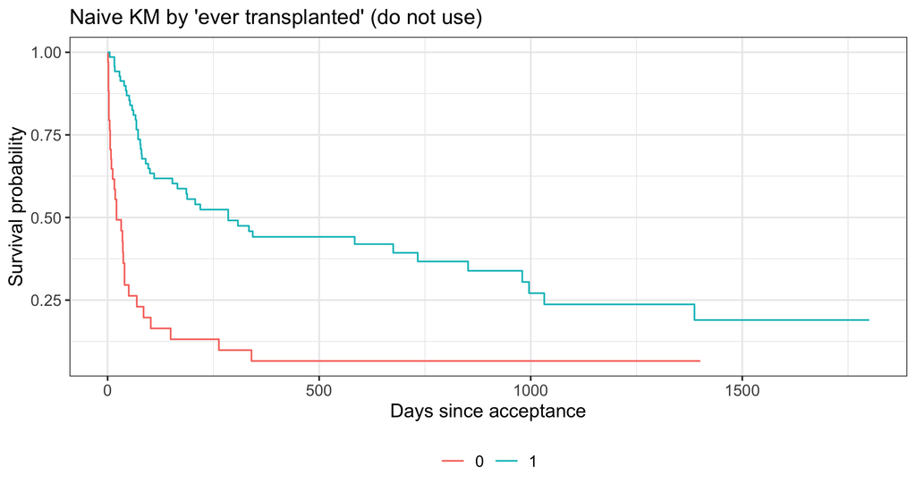

```r
survfit2(Surv(time, event) ~ ever_tx, data = heart_fixed) |>
  ggsurvfit() +
  labs(x = "Days since acceptance", y = "Survival probability",
       title = "Naive KM by 'ever transplanted' (do not use)")
```

The curves compare groups defined by the future. The early drop in the “never transplanted” group comes from patients who died before a donor could arrive.

## Number of deaths while waiting

```r
heart_fixed |>
  group_by(ever_tx) |>
  summarise(patients = n(), deaths = sum(event), median_follow_up = median(time))
```

```
# A tibble: 2 × 4
  ever_tx patients deaths median_follow_up
    <int>    <int>  <dbl>            <dbl>
1       0       34     30               21
2       1       69     45              207
```

## Alternative: landmark analysis

Choose a landmark time $t_L$ (here 30 days). Use only patients alive at $t_L$, classify by status **at $t_L$**, and start follow-up at $t_L$.

```r
tL <- 30
lm_dat <- heart |>
  filter(stop > tL) |>               # still alive and under observation at the landmark
  group_by(id) |>
  summarise(tx_by_L = as.integer(any(transplant == 1 & start < tL)),
            time = max(stop) - tL, event = max(event),
            age = first(age), surgery = first(surgery), year = first(year))

fit_lm <- coxph(Surv(time, event) ~ tx_by_L + age + surgery + year, data = lm_dat)
exp(cbind(HR = coef(fit_lm), confint(fit_lm)))["tx_by_L", ] |> round(2)
```

```
    HR  2.5 % 97.5 %
  0.92   0.53   1.61
```

Among 79 patients alive at day 30, 33 had been transplanted by then.

## Landmark versus time-dependent

|  | Time-dependent Cox | Landmark |
| --- | --- | --- |
| Uses all data | yes | no, only patients alive at $t_L$ |
| Allows exposure changes after $t_L$ | yes | ignored |
| Choice of $t_L$ | none | arbitrary, try several |
| Simple KM plot | no | yes |
| Effect | current-status HR | HR from $t_L$ onwards |

Landmark is easy to explain and plot; the time-dependent model is more efficient. Report the same conclusion from both when possible.

## Same pitfall, other disguises

- “Responders versus non-responders” to chemotherapy: response is only known after some weeks
- “Patients who completed treatment” versus those who did not
- “Statin users” defined by a prescription during follow-up
- GVHD: patients who develop GVHD must survive until onset

**Fix**: time-dependent covariate, landmark, or define groups at time 0.

## In-class exercise 1

A study follows 200 patients after a diagnosis. Patients who “respond to treatment within 6 months” have much longer survival than non-responders (HR 0.4, from a Cox model with response as baseline covariate).

1. Which part of the analysis is problematic?
2. Sketch the data layout for a patient who responds at month 3 and dies at month 20.
3. Name two alternative analyses.

# Testing PH and time-varying effects

## From lecture 6: coefficient depending on time

If the effect of $x$ changes with time, an extended model is

$$h(t \mid x) = h_0(t)\exp\{\beta(t)\, x\}, \qquad \beta(t) = \beta_0 + \beta_1 g(t)$$

- $g(t) = \log t$ is the common choice
- $H_0: \beta_1 = 0$ is a test of proportional hazards
- $\beta_1$ is the coefficient of the time-dependent covariate $x \log t$ (Collett writes this coefficient as $\gamma$: $\gamma = \beta_1$)
- Hazard ratio for a one-unit change in $x$ at time $t$: $\exp\{\beta_0 + \beta_1 \log t\}$

`cox.zph` tests essentially this (with a choice of time transformation).

## Example: PBC, bilirubin

```r
pbc2 <- pbc |> filter(!is.na(trt)) |> mutate(lbili = log(bili))
fit_ph <- coxph(Surv(time, status == 2) ~ lbili + age, data = pbc2)
cox.zph(fit_ph, transform = "log")
```

```
       chisq df     p
lbili  0.316  1 0.574
age    2.986  1 0.084
GLOBAL 3.281  2 0.194
```

## The same test with `tt()`

```r
fit_tt <- coxph(Surv(time, status == 2) ~ lbili + age + tt(lbili), data = pbc2,
                tt = function(x, t, ...) x * log(t))
broom::tidy(fit_tt) |> mutate(across(where(is.numeric), \(x) round(x, 3)))
```

```
# A tibble: 3 × 5
  term      estimate std.error statistic p.value
  <chr>        <dbl>     <dbl>     <dbl>   <dbl>
1 lbili        1.44      0.648     2.22    0.027
2 age          0.039     0.008     4.69    0
3 tt(lbili)   -0.053     0.095    -0.562   0.574
```

`tt(lbili)` is $\beta_1$. A p-value of 0.574 for the interaction with $\log t$. The sign of the coefficient tells in which direction the effect of log bilirubin drifts over time.

**Note**

`tt()` computes the covariate at each event time inside `coxph`; no data splitting is needed. It does not work well with time-dependent data already split, and `predict`/`survfit` are not supported for `tt` models.

## Step-function coefficients

Instead of a smooth $\log t$, let the effect differ between periods, e.g. 0-2 years, 2-4 years, 4+ years (cut points fixed in advance):

```r
cuts <- c(730, 1460)
pbc_split <- survSplit(Surv(time, status == 2) ~ lbili + age, data = pbc2,
                       cut = cuts, episode = "period") |>
  mutate(period = factor(period, labels = c("0-730", "731-1460", ">1460")))

fit_step <- coxph(Surv(tstart, time, event) ~ lbili:period + age, data = pbc_split)
broom::tidy(fit_step, exponentiate = TRUE, conf.int = TRUE) |>
  mutate(across(where(is.numeric), \(x) round(x, 2)))
```

```
# A tibble: 4 × 7
  term                 estimate std.error statistic p.value conf.low conf.high
  <chr>                   <dbl>     <dbl>     <dbl>   <dbl>    <dbl>     <dbl>
1 age                      1.04      0.01      4.72       0     1.02      1.06
2 lbili:period0-730        2.57      0.16      5.9        0     1.88      3.52
3 lbili:period731-1460     3.81      0.16      8.53       0     2.8       5.19
4 lbili:period>1460        2.47      0.17      5.39       0     1.78      3.44
```

Each row is the HR per unit of log bilirubin within that period. More interpretable than $x\log t$ and easily extended to other covariates. We pay with arbitrary cut points. The clinical use of step functions for non-PH (gastric cancer, piecewise HRs, HR(t) plot) follows in Lecture 11.

# Internal covariates

## Biomarker example: `pbc` and `pbcseq`

Mayo primary biliary cirrhosis trial. `pbcseq` has repeated lab values (with `day` of visit). Build the layout with `tmerge`:

```r
pbc_base <- pbc |> filter(id <= 312) |> select(id, age, sex, trt, time, status)
pbc_td <- tmerge(pbc_base, pbc_base, id = id, death = event(time, status == 2)) |>
  tmerge(pbcseq, id = id, bili = tdc(day, bili), albumin = tdc(day, albumin))
pbc_td |> filter(id %in% 1:2) |> select(id, tstart, tstop, death, bili, albumin)
```

```
   id tstart tstop death bili albumin
1   1      0   192 FALSE 14.5    2.60
2   1    192   400  TRUE 21.3    2.94
3   2      0   182 FALSE  1.1    4.14
4   2    182   365 FALSE  0.8    3.60
5   2    365   768 FALSE  1.0    3.55
6   2    768  1790 FALSE  1.9    3.92
7   2   1790  2151 FALSE  2.6    3.32
8   2   2151  2515 FALSE  3.6    2.92
9   2   2515  2882 FALSE  4.2    2.73
10  2   2882  3226 FALSE  3.6    2.80
11  2   3226  4500 FALSE  4.6    2.67
```

1807 rows for 312 patients.

## Fitting

```r
fit_bio <- coxph(Surv(tstart, tstop, death) ~ log(bili) + albumin + age, data = pbc_td)
broom::tidy(fit_bio, exponentiate = TRUE, conf.int = TRUE) |>
  mutate(across(where(is.numeric), \(x) round(x, 3)))
```

```
# A tibble: 3 × 7
  term      estimate std.error statistic p.value conf.low conf.high
  <chr>        <dbl>     <dbl>     <dbl>   <dbl>    <dbl>     <dbl>
1 log(bili)     3.88     0.122     11.1        0    3.05      4.93
2 albumin       0.16     0.198     -9.24       0    0.108     0.236
3 age           1.04     0.01       4.54       0    1.02      1.06
```

Interpretation: a doubling of the **current** bilirubin multiplies the current hazard by $2^{\hat\beta}$ = 2.56, for given current albumin and age. The estimate is an association with the **current level**, not a baseline risk prediction.

## Warnings for internal covariates

**Warning**

- The marker is only observed while the patient is alive: it carries information about **survival itself**
- It is a **mediator**: if treatment acts through bilirubin, adjusting for current bilirubin hides the treatment effect
- Measurement error typically attenuates the HR (towards the null); carrying values forward (LOCF) also biases the estimate, but with no fixed direction
- Visits may depend on health (sicker patients are measured more often)
- **Prediction**: the model gives $h(t \mid x(t))$, not $S(t)$ for a new patient, because the future path of $x(t)$ is unknown; `survfit` curves for a fixed $x$ are not survival curves for a real patient

Joint models for longitudinal and survival data (Collett Section 8.7) model the biomarker path and the hazard together, and are the standard tool for such problems. We only mention the name here.

## Which analysis to choose?

| Covariate | Suggestion |
| --- | --- |
| Known at time 0 | Standard Cox |
| Treatment starting later | Time-dependent covariate (or landmark) |
| External (age, calendar time) | Time-dependent covariate / split |
| Internal biomarker, association | Time-dependent covariate, with care |
| Internal biomarker, prediction | Landmark or joint model |
| Check PH | $x\log t$ via `tt()`, `cox.zph` |

## In-class exercise 2

Use the `cirr` data.

1. How many rows has patient 3 and what are the intervals?
2. Fit `coxph(Surv(start, stop, status) ~ treat + lbrt, data = cirr)`. Interpret the HR of `lbrt`.
3. What goes wrong if you take only the **last** `lbrt` value of each patient and fit a fixed-covariate model?

## Quiz

1. For a patient who is transplanted at day 50 and dies at day 120, give the (start, stop, event) rows.
2. True or false: with a time-dependent covariate, the HR between two patients is constant over time.
3. Why can’t you predict an individual survival curve from a model with an internal time-dependent biomarker?

## Take-home messages

- Time-dependent covariates: $h(t) = h_0(t)\exp\{\beta' x(t)\}$, with $x(t)$ evaluated at each event time
- Data go in **counting-process** format; use `tmerge()` and `survSplit()`
- `coxph(Surv(start, stop, event) ~ ...)` fits the model; the HR refers to the **current** value
- **Never** classify patients by future events at baseline: immortal time bias. Stanford heart: naive HR 0.18 versus time-dependent HR 0.99
- Landmark analysis is a simple alternative
- Time-dependent terms such as $x\log t$ test PH and let effects vary with time
- Internal biomarkers: association only; prediction and causal claims need more (joint models)

**Next lecture**: non-proportional hazards (Collett, Chapter 11).

**Reading**: Collett, Chapter 8 (Sections 8.1-8.6; 8.7 on joint models is optional).